# Fall 2024 VIE PreAssignment

Ted Kwartler

2024-10-04

# Pre-class Assignment: Introduction to R for Business Analytics

## Setup

I assume you can install R and R-Studio. Further, as a new R programmer you will need to use the following commands one time to install libraries used in this pre-assignment.

`install.pakages('some library name')`

## Objective

The aim of this pre-assignment is help you catch up to others in the cohort that attended the Harvard session. This is meant to help you familiarize yourself with R. Your learning objectives include:

1. Loading data into R
2. Perform basic exploratory data analysis (EDA).
3. Create visualizations using ggplot2 (and I also like ggthemes).
4. Fit a basic linear regression model and interpret its output. My expectation is that you understand a linear regression as its from statistics and shouldn’t be complicated. Remember you can always look up on an LLM, stackoverflow or google search.
5. Examine the model and identify some relevant KPIs.

## Data

- “Row.ID”
- “Order.ID”
- “Order.Date”
- “Ship.Date”
- “Ship.Mode”
- “Customer.ID”
- “Customer.Name”
- “Segment”
- “City”
- “State”
- “Country”
- “Postal.Code”
- “Market”
- “Region”
- “Product.ID”
- “Category”
- “Sub.Category”
- “Product.Name”
- “Sales”
- “Quantity”
- “Discount”
- “Profit”
- “Shipping.Cost”
- “Order.Priority”

The data containts product sales & profits making it realistic and business-related.

## Instructions

### Step 1: Load the Data

You’ll be loading data from a CSV file into R which requires the `read.csv` function. The URL is to our class repository but you could also change it to a local path too.

```r
# Load Data, create an object called SuperstoreData with the correct table reading function
SuperstoreData <- read.csv("https://github.com/kwartler/Vienna_24/raw/refs/heads/main/Fall_2024/superstore_dataset2011-2015.csv")
```

### Step 2: Explore the Data

Use the `str()`, `class()` and `summary()` functions to understand the data. Find the function that let’s you *examine the top 6 rows by default and put it in this section*.

```r
# Check the structure of data
str(SuperstoreData)
```

```
## 'data.frame':    51290 obs. of  24 variables:
##  $ Row.ID        : int  42433 22253 48883 11731 22255 22254 21613 34662 44508 23688 ...
##  $ Order.ID      : chr  "AG-2011-2040" "IN-2011-47883" "HU-2011-1220" "IT-2011-3647632" ...
##  $ Order.Date    : chr  "1/1/2011" "1/1/2011" "1/1/2011" "1/1/2011" ...
##  $ Ship.Date     : chr  "6/1/2011" "8/1/2011" "5/1/2011" "5/1/2011" ...
##  $ Ship.Mode     : chr  "Standard Class" "Standard Class" "Second Class" "Second Class" ...
##  $ Customer.ID   : chr  "TB-11280" "JH-15985" "AT-735" "EM-14140" ...
##  $ Customer.Name : chr  "Toby Braunhardt" "Joseph Holt" "Annie Thurman" "Eugene Moren" ...
##  $ Segment       : chr  "Consumer" "Consumer" "Consumer" "Home Office" ...
##  $ City          : chr  "Constantine" "Wagga Wagga" "Budapest" "Stockholm" ...
##  $ State         : chr  "Constantine" "New South Wales" "Budapest" "Stockholm" ...
##  $ Country       : chr  "Algeria" "Australia" "Hungary" "Sweden" ...
##  $ Postal.Code   : int  NA NA NA NA NA NA NA 92691 NA NA ...
##  $ Market        : chr  "Africa" "APAC" "EMEA" "EU" ...
##  $ Region        : chr  "Africa" "Oceania" "EMEA" "North" ...
##  $ Product.ID    : chr  "OFF-TEN-10000025" "OFF-SU-10000618" "OFF-TEN-10001585" "OFF-PA-10001492" ...
##  $ Category      : chr  "Office Supplies" "Office Supplies" "Office Supplies" "Office Supplies" ...
##  $ Sub.Category  : chr  "Storage" "Supplies" "Storage" "Paper" ...
##  $ Product.Name  : chr  "Tenex Lockers, Blue" "Acme Trimmer, High Speed" "Tenex Box, Single Width" "Enermax Note Cards, Premium" ...
##  $ Sales         : num  408.3 120.4 66.1 44.9 113.7 ...
##  $ Quantity      : int  2 3 4 3 5 2 2 2 1 3 ...
##  $ Discount      : num  0 0.1 0 0.5 0.1 0.1 0 0.15 0 0 ...
##  $ Profit        : num  106.1 36 29.6 -26.1 37.8 ...
##  $ Shipping.Cost : num  35.46 9.72 8.17 4.82 4.7 ...
##  $ Order.Priority: chr  "Medium" "Medium" "High" "High" ...
```

```r
# What class is this object?
class(SuperstoreData)
```

```
## [1] "data.frame"
```

```r
# Obtain summary statistics
summary(SuperstoreData)
```

```
##      Row.ID        Order.ID          Order.Date         Ship.Date
##  Min.   :    1   Length:51290       Length:51290       Length:51290
##  1st Qu.:12823   Class :character   Class :character   Class :character
##  Median :25646   Mode  :character   Mode  :character   Mode  :character
##  Mean   :25646
##  3rd Qu.:38468
##  Max.   :51290
##
##   Ship.Mode         Customer.ID        Customer.Name        Segment
##  Length:51290       Length:51290       Length:51290       Length:51290
##  Class :character   Class :character   Class :character   Class :character
##  Mode  :character   Mode  :character   Mode  :character   Mode  :character
##
##
##
##
##      City              State             Country           Postal.Code
##  Length:51290       Length:51290       Length:51290       Min.   : 1040
##  Class :character   Class :character   Class :character   1st Qu.:23223
##  Mode  :character   Mode  :character   Mode  :character   Median :56430
##                                                           Mean   :55190
##                                                           3rd Qu.:90008
##                                                           Max.   :99301
##                                                           NA's   :41296
##     Market             Region           Product.ID          Category
##  Length:51290       Length:51290       Length:51290       Length:51290
##  Class :character   Class :character   Class :character   Class :character
##  Mode  :character   Mode  :character   Mode  :character   Mode  :character
##
##
##
##
##  Sub.Category       Product.Name           Sales              Quantity
##  Length:51290       Length:51290       Min.   :    0.444   Min.   : 1.000
##  Class :character   Class :character   1st Qu.:   30.759   1st Qu.: 2.000
##  Mode  :character   Mode  :character   Median :   85.053   Median : 3.000
##                                        Mean   :  246.491   Mean   : 3.477
##                                        3rd Qu.:  251.053   3rd Qu.: 5.000
##                                        Max.   :22638.480   Max.   :14.000
##
##     Discount          Profit         Shipping.Cost    Order.Priority
##  Min.   :0.0000   Min.   :-6599.98   Min.   :  0.00   Length:51290
##  1st Qu.:0.0000   1st Qu.:    0.00   1st Qu.:  2.61   Class :character
##  Median :0.0000   Median :    9.24   Median :  7.79   Mode  :character
##  Mean   :0.1429   Mean   :   28.61   Mean   : 26.38
##  3rd Qu.:0.2000   3rd Qu.:   36.81   3rd Qu.: 24.45
##  Max.   :0.8500   Max.   : 8399.98   Max.   :933.57
##
```

```r
# Examine the top 6 rows using a function
head(SuperstoreData)
```

```
##   Row.ID        Order.ID Order.Date Ship.Date      Ship.Mode Customer.ID
## 1  42433    AG-2011-2040   1/1/2011  6/1/2011 Standard Class    TB-11280
## 2  22253   IN-2011-47883   1/1/2011  8/1/2011 Standard Class    JH-15985
## 3  48883    HU-2011-1220   1/1/2011  5/1/2011   Second Class      AT-735
## 4  11731 IT-2011-3647632   1/1/2011  5/1/2011   Second Class    EM-14140
## 5  22255   IN-2011-47883   1/1/2011  8/1/2011 Standard Class    JH-15985
## 6  22254   IN-2011-47883   1/1/2011  8/1/2011 Standard Class    JH-15985
##     Customer.Name     Segment        City           State   Country Postal.Code
## 1 Toby Braunhardt    Consumer Constantine     Constantine   Algeria          NA
## 2     Joseph Holt    Consumer Wagga Wagga New South Wales Australia          NA
## 3   Annie Thurman    Consumer    Budapest        Budapest   Hungary          NA
## 4    Eugene Moren Home Office   Stockholm       Stockholm    Sweden          NA
## 5     Joseph Holt    Consumer Wagga Wagga New South Wales Australia          NA
## 6     Joseph Holt    Consumer Wagga Wagga New South Wales Australia          NA
##   Market  Region       Product.ID        Category Sub.Category
```

[output cut: 20 more lines]

### Step 3: Visualization

Your business audience will be able to understand a lot of patterns with compelling visuals. Build a scatter plot using `ggplot` so x is “Discount” and y is “Profit”. Also, find the function to `correlate both of these variables and put it in this code chunk`. You can also use `ggthemes` to add a theme layer so its more appealing.

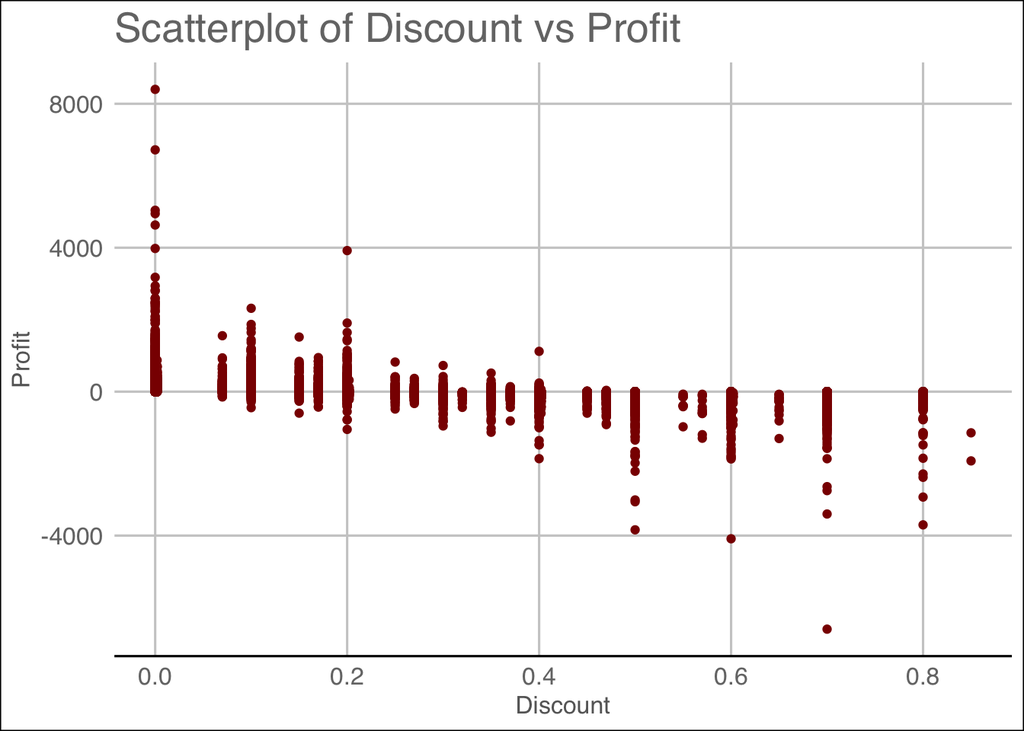

```r
# Load the ggplot2 & ggthemes library
library(ggplot2)
library(ggthemes)

# Scatter plot of Discount vs. Profit
# add a ggtitle() with  "Scatterplot of Discount vs Profit"
# Make the visual have a google theme from ggthemes
# make the points darkred
ggplot(SuperstoreData, aes(x = Discount, y = Profit)) +
  geom_point(color = 'darkred') +
  ggtitle("Scatterplot of Discount vs Profit") +
  theme_gdocs()
```

```r
# What is the correlation between Discount & Profit?
cor(SuperstoreData$Discount, SuperstoreData$Profit)
```

```
## [1] -0.3164902
```

### Step 4: Fit a Regression Model

Now, we’ll use a linear regression model to test if “Discount”, “Quantity”, & “Shipping.Cost” can predict the “Profit”. You will need to setup a formula in this format:

`y ~ variable1 + variable2 + variable3`

```r
# Fit a simple linear regression model
fit <- lm(Profit ~ Discount + Quantity + Shipping.Cost, data = SuperstoreData)

# Print model `summary()`
summary(fit)
```

```
##
## Call:
## lm(formula = Profit ~ Discount + Quantity + Shipping.Cost, data = SuperstoreData)
##
## Residuals:
##     Min      1Q  Median      3Q     Max
## -6922.6   -33.0   -14.5    30.9  8013.1
##
## Coefficients:
##                 Estimate Std. Error t value Pr(>|t|)
## (Intercept)     33.91215    1.34005  25.307   <2e-16 ***
## Discount      -238.41625    3.23460 -73.708   <2e-16 ***
## Quantity         0.67895    0.31221   2.175   0.0297 *
## Shipping.Cost    1.00129    0.01245  80.403   <2e-16 ***
## ---
## Signif. codes:  0 '***' 0.001 '**' 0.01 '*' 0.05 '.' 0.1 ' ' 1
##
## Residual standard error: 155 on 51286 degrees of freedom
## Multiple R-squared:  0.2094, Adjusted R-squared:  0.2094
## F-statistic:  4529 on 3 and 51286 DF,  p-value: < 2.2e-16
```

### Step 5: Assess the Model

Interpret the model results. Examine the model’s coefficients, adjusted R-squared & p-values.

Some questions to consider:

- How well does the model explain the variation?
- Are the model’s predictors significant?

Write your observations.

## Deliverable

Submit your well-structured, thoroughly-commented R script including outputs. Also, provide your interpretation and insights obtained from the regression model.